# Causal thinking

Linking Scientific and statistical models

| Diogo Melo Lewis-Sigler Institute of Integrative Genomics damelo@princeton.edu |
| --- |

## what are models for?

### prediction vs causal inference

### Causation and correlation

Why does correlation not imply causation?

### graph model representation

We can use graphs to represent our putative causal model. An arrow between variables represents a potential causal effect.

[figure not shown]

## Causal inference intro

[figure not shown]

## Pipes, forks, colliders

### elemental triads

The pipe

[figure not shown]

The fork

[figure not shown]

The collider

[figure not shown]

### simulating confounds

How does a confound affect our estimate of the effect of x on y?

[figure not shown]

## Fork

### Direct effect of x on y, plus confounder z

[figure not shown]

Generative model implied by this DAG:

### Model without the confounder

[figure not shown]

Statistical model without the confounder:

### ulam model without the confounder

[figure not shown]

```python
N = 100
z = rnorm(N)            # z ~ normal(0, 1)
x = rnorm(N, 1 + z)     # x ~ normal(1 + z, 1)
y = rnorm(N, 1 + x + z) # y ~ normal(1 + x + z, 1)

m1 = ulam(alist(
    y ~ normal(a + bx*x, sigma),
    a ~ normal(0, 0.3),
    bx ~ normal(0, 0.3),
    sigma ~ exponential(1)
), data = list(y = y, x = x))
```

### model estimates without the confounder

[figure not shown]

```python
> precis(m1)
      mean   sd 5.5% 94.5% n_eff Rhat4
a     0.54 0.14 0.32  0.77  1274     1
bx    1.47 0.08 1.34  1.60  1432     1  # Estimate of the effect of x on y
sigma 1.33 0.10 1.19  1.49  1418     1
```

### without the confounder

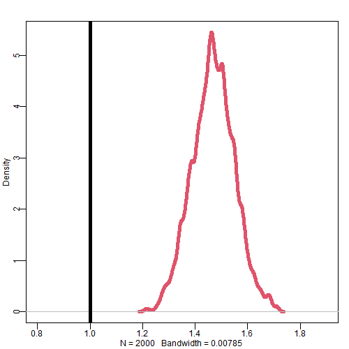

### Including the confounder

```python
m2 = ulam(alist(
    y ~ normal(a + bx*x + bz*z, sigma),
    a ~ normal(0, 0.3),
    bx ~ normal(0, 0.3),
    bz ~ normal(0, 0.3),   # New parameter for confounder
    sigma ~ exponential(1)
), data = list(y = y, x = x, z = z))
> precis(m2)
       mean   sd 5.5% 94.5% n_eff Rhat4
a      0.95 0.14 0.72  1.17   942     1
bx     1.06 0.10 0.91  1.22   837     1
bz     0.82 0.12 0.62  1.02   889     1
sigma  1.09 0.08 0.97  1.22  1200     1
```

### with the confounder

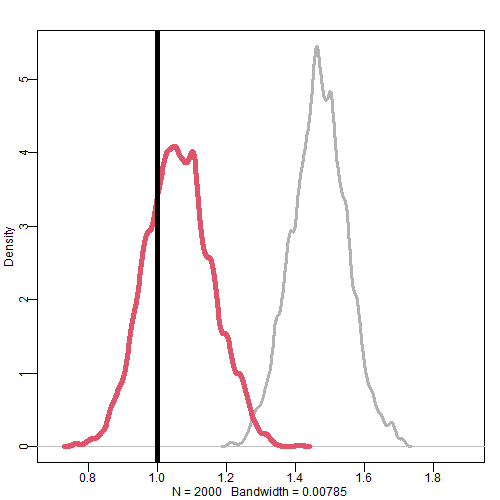

### Examples of forks or confounders

- This is the quintessential “control” variable.
- Most variables are included in the model under the assumption that they are confounders and need have their effects taken into consideration.

[figure not shown]

### Smoking and cancer

Famously, R. A. Fisher was not convinced that smoking caused cancer, and proposed that an unobserved propensity variable caused both cancer and smoking

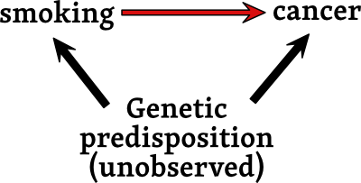

### omitted variable bias

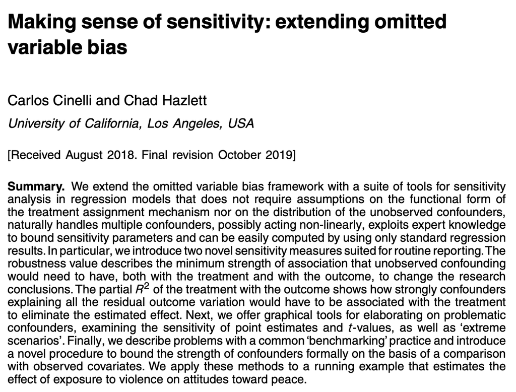

- Carlos Cinelli and Chad Hazlett (2020) [1]

### Species distributions

Maybe want to evaluate the effect of some predator on the distribution of a prey. But the spacial distribution of both the predator and the prey are affected by some abiotic factor:

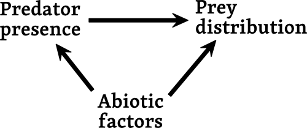

## Pipe

### All the effect of x on y is mediated by z

[figure not shown]

Generative model implied by this DAG:

### Model without the mediator

[figure not shown]

```python
set.seed(1)
N = 100
x = rnorm(N)        # x ~ normal(0, 1)
z = rnorm(N, 1 + x) # z ~ normal(1 + x, 1)
y = rnorm(N, 1 + z) # y ~ normal(1 + z, 1)

m1 = ulam(alist(
    y ~ normal(a + bx*x, sigma),
    a ~ normal(0, 0.3),
    bx ~ normal(0, 0.3),
    sigma ~ exponential(1)
), data = list(y = y, x = x), iter = 1000, chains = 4, cores = 4)
```

### without the mediator

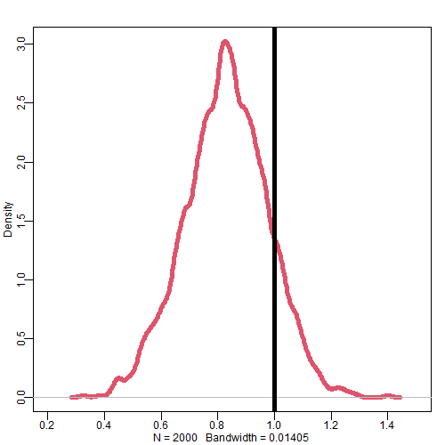

```python
m1 = ulam(alist(
    y ~ normal(a + bx*x, sigma),
    a ~ normal(0, 0.3),
    bx ~ normal(0, 0.3),
    sigma ~ exponential(1)
), data = list(y = y, x = x), iter = 1000, chains = 4, cores = 4)
```

### Including the mediator

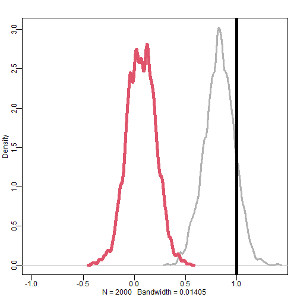

```python
m2 = ulam(alist(
    y ~ normal(a + bx*x + bz*z, sigma),
    a ~ normal(0, 0.3),
    bx ~ normal(0, 0.3),
    bz ~ normal(0, 0.3), # Mediator
    sigma ~ exponential(1)
), data = list(y = y, x = x, z = z), iter = 1000, chains = 4, cores = 4)
```

### Pipe vs Fork

[figure not shown]

### Examples of pipes or mediators

Including a mediator in our models can have catastrophic effects. A common mistake is to include post-treatment variables in the model.

[figure not shown]

### Post-treatment variables

If we are evaluating the effectiveness of a fungal treatment, most of the effect of the treatment could be mediated by the presence of fungus. So, using presence of fungus in our model would mask the effect of the treatment.

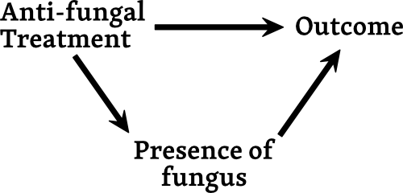

### Conditioning on Posttreatment Variables

[figure not shown]

Montgomery et al. 2018[2]

## Collider

### No effect of x on y, but both affect z

[figure not shown]

Generative model implied by this DAG:

### Model without the collider

[figure not shown]

```python
set.seed(1)
N = 100
x = rnorm(N)            # x ~ normal(0, 1)
y = rnorm(N)            # y ~ normal(0, 1)
z = rnorm(N, 1 + x + y) # z ~ normal(1 + x + y, 1) -> collider

m1 = ulam(alist(
    y ~ normal(a + bx*x, sigma),
    a ~ normal(0, 0.3),
    bx ~ normal(0, 0.3),
    sigma ~ exponential(1)
), data = list(y = y, x = x), iter = 1000, chains = 4, cores = 4)
```

### without the collider

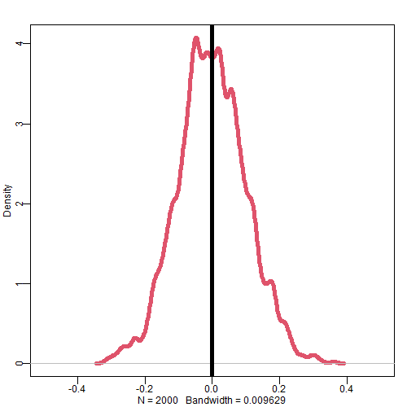

```python
m1 = ulam(alist(
    y ~ normal(a + bx*x, sigma),
    a ~ normal(0, 0.3),
    bx ~ normal(0, 0.3),
    sigma ~ exponential(1)
), data = list(y = y, x = x), iter = 1000, chains = 4, cores = 4)
```

### with the collider

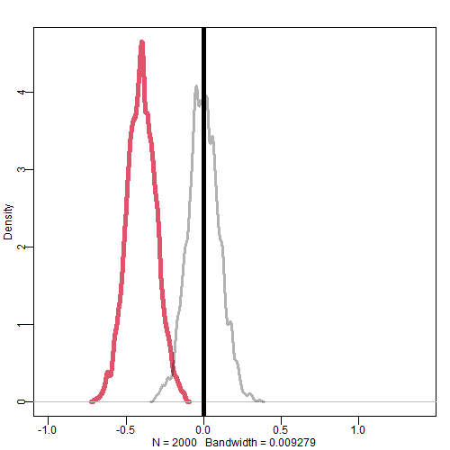

```python
m2 = ulam(alist(
    y ~ normal(a + bx*x + bz*z, sigma),
    a ~ normal(0, 0.3),
    bx ~ normal(0, 0.3),
    bz ~ normal(0, 0.3), # Collider
    sigma ~ exponential(1)
), data = list(y = y, x = x, z = z), iter = 1000, chains = 4, cores = 4)
```

### Colliders can cause our samples to be biased

### using dags to build models

If we represent our putative causal relations using DAGs, we have a set of rules that tells us what variables we need to include in the model in order to calculate a particular effect.

- Automated tool: [dagitty.net](http://www.dagitty.net/dags.html)

### Open and closed paths

- Paths containing uncontrolled pipes and forks are open
- Paths containing colliders are closed by default, but open if we condition on the collider

### Identify all the open paths from X to Y

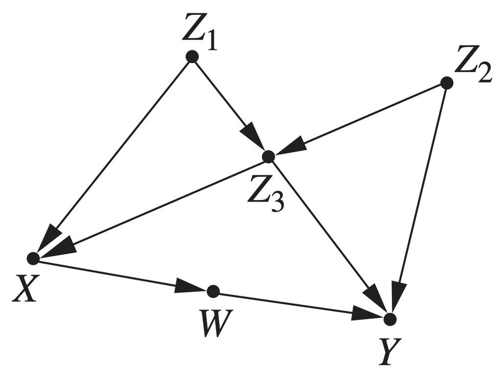

### Back door criterion

To estimate the causal effect of X on Y, identify a set of control variables such that no descendants of X are in the control set, and all paths between X and Y that contain an arrow into X are blocked.

### Not all estimates are causal

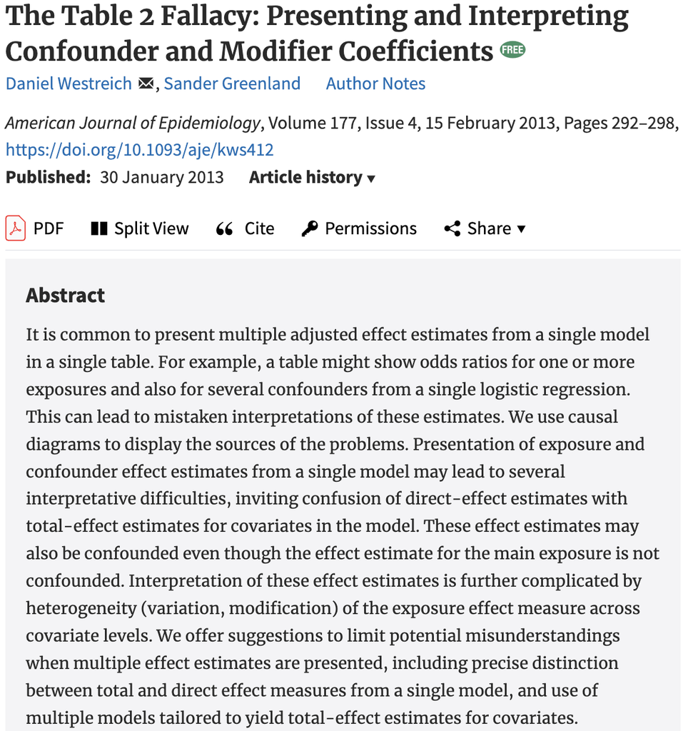

- Westreich et al. [3]

## Table 1

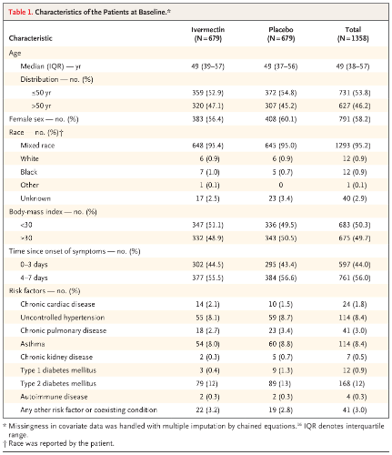

## Table 2

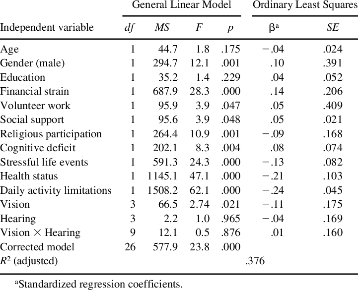

### Hiv and stroke

[figure not shown]

### good controls

- Block non-causal paths
- Improve precision
- Allow inference of causal effects

### bad controls

- Block causal paths (blocking pipes)
- Open non-causal paths (opening colliders)
- Reduce precision
- Prevent causal inference

### references

[1]Carlos Cinelli, and Chad Hazlett. “Making Sense of Sensitivity: Extending Omitted Variable Bias.” *J. R. Stat. Soc. Series B Stat. Methodol.* 82 (1). Wiley: 39–67. Feb. 2020. doi:10.1111/rssb.12348. [🔎](http://www.bing.com/search?q=Making%20sense%20of%20sensitivity%3A%20extending%20omitted%20variable%20bias%20Cinelli%20and%20Hazlett%2C%202020)

[2]Jacob M Montgomery, Brendan Nyhan, and Michelle Torres. “How Conditioning on Posttreatment Variables Can Ruin Your Experiment and What to Do about It.” *Am. J. Pol. Sci.* 62 (3). Wiley: 760–775. Jul. 2018. doi:10.1111/ajps.12357. [🔎](http://www.bing.com/search?q=How%20conditioning%20on%20posttreatment%20variables%20can%20ruin%20your%20experiment%20and%20what%20to%20do%20about%20it%20Montgomery%2C%20Nyhan%2C%20and%20Torres%2C%202018)

[3]Daniel Westreich, and Sander Greenland. “The Table 2 Fallacy: Presenting and Interpreting Confounder and Modifier Coefficients.” *Am. J. Epidemiol.* 177 (4): 292–298. Feb. 2013. doi:10.1093/aje/kws412. [🔎](http://www.bing.com/search?q=The%20table%202%20fallacy%3A%20presenting%20and%20interpreting%20confounder%20and%20modifier%20coefficients%20Westreich%20and%20Greenland%2C%202013)